# Carbon_Emissions Analysis Using Regression, Knn, Anova, Clustering, Association Rules

Elias

2025-11-09

#### Introduction:

#### This project analyzes global CO₂ emissions to understand how population growth and temperature changes influence emission patterns.

#### Goal:

#### To identify key relationships, classify emission levels, and group countries using regression, KNN, ANOVA, clustering, and association rules.

# [1]: Inspecting the Structure and Getting an Overview

```r
library(readr)
# Loading my dataset
C02_data <- read_csv("C:/Users/bzimb/Desktop/DA Proj/C02_data.csv")
View(C02_data)


head(C02_data)
```

```
## # A tibble: 6 × 6
##    year population temperature_change_from_co2 consumption_co2   co2 country
##   <dbl>      <dbl>                       <dbl>           <dbl> <dbl> <chr>
## 1  1990  643775320                       0.042            583.  658. Africa
## 2  1991  661103806                       0.043            607.  688. Africa
## 3  1992  678558076                       0.044            620.  667. Africa
## 4  1993  696621727                       0.044            643.  706. Africa
## 5  1994  714502658                       0.045            716.  790. Africa
## 6  1995  732695476                       0.046            752.  845. Africa
```

```r
summary(C02_data)
```

```
##       year        population        temperature_change_from_co2
##  Min.   :1990   Min.   :2.553e+05   Min.   :0.00100
##  1st Qu.:1998   1st Qu.:5.398e+06   1st Qu.:0.00100
##  Median :2006   Median :1.410e+07   Median :0.00300
##  Mean   :2006   Mean   :2.145e+08   Mean   :0.03517
##  3rd Qu.:2014   3rd Qu.:5.819e+07   3rd Qu.:0.01100
##  Max.   :2023   Max.   :8.092e+09   Max.   :1.16100
##                                     NA's   :843
##  consumption_co2          co2              country
##  Min.   :    0.084   Min.   :    0.455   Length:4369
##  1st Qu.:    9.940   1st Qu.:    7.958   Class :character
##  Median :   49.935   Median :   45.034   Mode  :character
##  Mean   :  948.098   Mean   :  955.180
##  3rd Qu.:  254.129   3rd Qu.:  270.715
##  Max.   :37791.566   Max.   :37791.570
##
```

```r
str(C02_data)
```

```
## spc_tbl_ [4,369 × 6] (S3: spec_tbl_df/tbl_df/tbl/data.frame)
##  $ year                       : num [1:4369] 1990 1991 1992 1993 1994 ...
##  $ population                 : num [1:4369] 6.44e+08 6.61e+08 6.79e+08 6.97e+08 7.15e+08 ...
##  $ temperature_change_from_co2: num [1:4369] 0.042 0.043 0.044 0.044 0.045 0.046 0.047 0.048 0.049 0.05 ...
##  $ consumption_co2            : num [1:4369] 583 607 620 643 716 ...
##  $ co2                        : num [1:4369] 658 688 667 706 790 ...
##  $ country                    : chr [1:4369] "Africa" "Africa" "Africa" "Africa" ...
##  - attr(*, "spec")=
##   .. cols(
##   ..   year = col_double(),
##   ..   population = col_double(),
##   ..   temperature_change_from_co2 = col_double(),
##   ..   consumption_co2 = col_double(),
##   ..   co2 = col_double(),
##   ..   country = col_character()
##   .. )
##  - attr(*, "problems")=<externalptr>
```

```r
colSums(is.na(C02_data))
```

```
##                        year                  population
##                           0                           0
## temperature_change_from_co2             consumption_co2
##                         843                           0
##                         co2                     country
##                           0                           0
```

#### [1]:

##### - Missing values are present in temperature_change_from_co2 (843 NAs) ; all other variables are complete.

##### - Summary statistics show wide variation: population ranges from ~255,000 to ~8 billion, co2 ranges from 0.455 to 37,791, and temperature change variables have small numeric scales but some outliers.

##### - All numeric variables are of type double and country is character, making the dataset ready for preprocessing and further analysis.

# [2] Handling the missing Values

```r
C02_data$temperature_change_from_co2[is.na(C02_data$temperature_change_from_co2)] <- median(C02_data$temperature_change_from_co2, na.rm = TRUE)

colSums(is.na(C02_data))
```

```
##                        year                  population
##                           0                           0
## temperature_change_from_co2             consumption_co2
##                           0                           0
##                         co2                     country
##                           0                           0
```

### [2]

##### - Missing values in ‘temperature_change_from_co2’ (843 NAs) were replaced with the median of their respective columns.

##### - After imputation, all variables have complete data with no missing values, making the dataset ready for further analysis.

# [3] Checking for outliers and Relationships

## CO2 VS Population Relationship

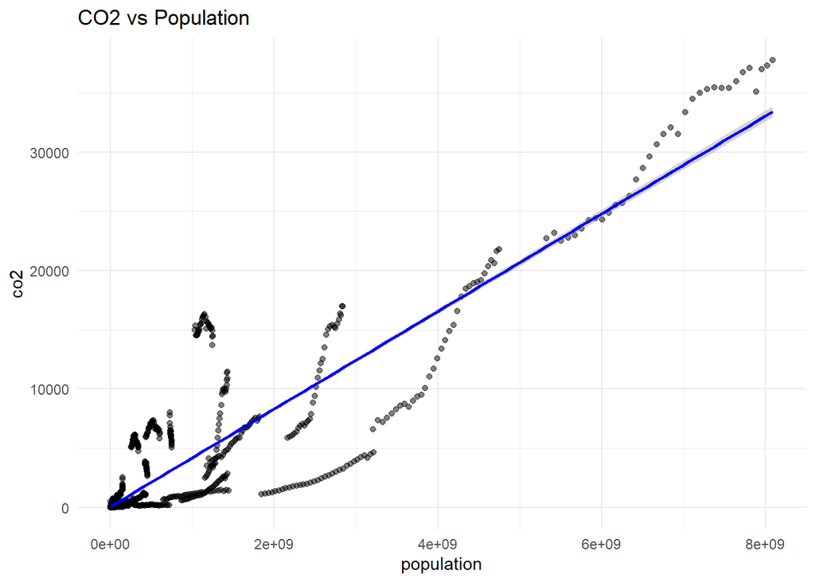

```r
library(ggplot2)

# Scatterplot CO2 vs Population
ggplot(C02_data, aes(x = population, y = co2)) +
  geom_point(alpha = 0.5) +
  geom_smooth(method = "lm", color = "blue") +
  ggtitle("CO2 vs Population") +
  theme_minimal()
```

### [3 - i]

##### The upward slope of the blue regression line indicates that as population increases, CO2 emissions tend to increase as well.

## Temp VS CO2 Relationship

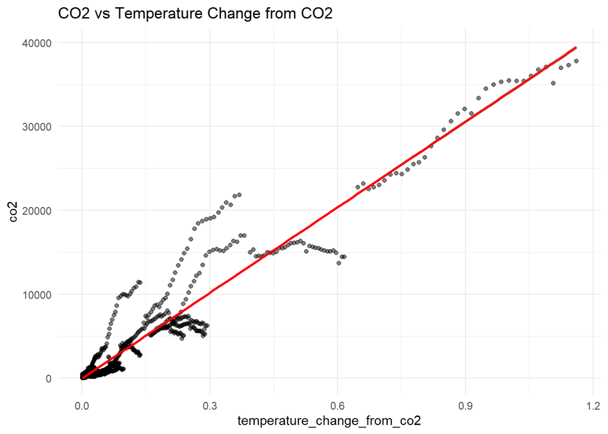

```r
# CO2 vs Temperature Change from CO2

ggplot(C02_data, aes(x = temperature_change_from_co2, y = co2)) +
  geom_point(alpha = 0.5) +
  geom_smooth(method = "lm", color = "red") +
  ggtitle("CO2 vs Temperature Change from CO2") +
  theme_minimal()
```

### [3 - ii]

##### The plot reveals a very strong, positive, and predominantly linear relationship between the two variables - temperature_change_from_co2 and Co2 .

##### This indicates that as total CO2 emissions increase, the temperature change attributed to CO2 increases in a highly predictable, linear fashion.

## - corplot

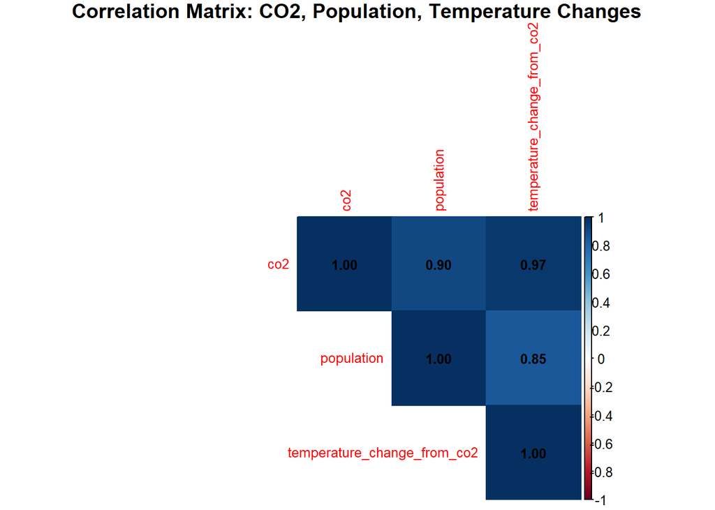

```r
 library(corrplot)
#Im will Select only CO2, population, and temperature change columns here
subset_numeric <- C02_data[, c("co2", "population", "temperature_change_from_co2")]

##### Getting the correlation matrix
cor_matrix_subset <- cor(subset_numeric, use = "complete.obs")

# Plotting correlation matrix
corrplot(cor_matrix_subset, method = "color", type = "upper",
         addCoef.col = "black", tl.cex = 0.8, number.cex = 0.8,
         title = "Correlation Matrix: CO2, Population, Temperature Changes", mar=c(0,0,1,0))
```

### [3 - iii]

##### - CO2 is strongly positively correlated with population (0.90) and temperature_change_from_co2 (0.97), indicating that as population and temperature change increase, CO2 emissions also rise.

##### Population also has strong positive correlations with the temperature change variables (temperature_change_from_co2 0.85 showing that larger populations are associated with higher temperature impacts.

# [4]: Regression Analysis

## CO2 ~ Population

```r
# Performing Linear regression: CO2 as a function of population

lm_co2_pop <- lm(co2 ~ population, data = C02_data)


summary(lm_co2_pop)
```

```
##
## Call:
## lm(formula = co2 ~ population, data = C02_data)
##
## Residuals:
##     Min      1Q  Median      3Q     Max
## -8841.6  -121.6   -73.0   -29.3 11505.4
##
## Coefficients:
##              Estimate Std. Error t value Pr(>|t|)
## (Intercept) 7.080e+01  2.379e+01   2.976  0.00294 **
## population  4.122e-06  2.944e-08 140.001  < 2e-16 ***
## ---
## Signif. codes:  0 '***' 0.001 '**' 0.01 '*' 0.05 '.' 0.1 ' ' 1
##
## Residual standard error: 1516 on 4367 degrees of freedom
## Multiple R-squared:  0.8178, Adjusted R-squared:  0.8178
## F-statistic: 1.96e+04 on 1 and 4367 DF,  p-value: < 2.2e-16
```

## [4 - i]

##### - R-squared (0.818): About 81.8% of the variance in CO2 emissions is explained by population alone.

##### - - Significance: Extremely significant (p-value < 2e-16), indicating a very strong linear relationship.

## CO2 ~ Temperature Change from CO2

```r
# Performing Linear regression: CO2 as a function of temperature_change_from_co2
lm_co2_temp <- lm(co2 ~ temperature_change_from_co2, data = C02_data)

# View summary
summary(lm_co2_temp)
```

```
##
## Call:
## lm(formula = co2 ~ temperature_change_from_co2, data = C02_data)
##
## Residuals:
##     Min      1Q  Median      3Q     Max
## -6781.3   -67.3    -4.4    28.9  9465.4
##
## Coefficients:
##                             Estimate Std. Error t value Pr(>|t|)
## (Intercept)                   -29.42      14.10  -2.087    0.037 *
## temperature_change_from_co2 33995.57     134.04 253.622   <2e-16 ***
## ---
## Signif. codes:  0 '***' 0.001 '**' 0.01 '*' 0.05 '.' 0.1 ' ' 1
##
## Residual standard error: 895.6 on 4367 degrees of freedom
## Multiple R-squared:  0.9364, Adjusted R-squared:  0.9364
## F-statistic: 6.432e+04 on 1 and 4367 DF,  p-value: < 2.2e-16
```

## [4 - ii]

##### - R-squared (0.936): 93.6% of CO2 variation is explained by temperature change, a very strong relationship.

##### - - Significance: Extremely significant (p-value < 2.2e-16), confirming a highly predictive model.

### [4 iiii] Both population and temperature change significantly explain the Carbon emissions.

# KNN (K-Nearest Neighbors)

### KNN (Predicting CO₂ Emissions)

```r
 library(class)
# 1. Creating categorical CO2 levels (Low, Medium, High)
C02_data$CO2_Level <- cut(
  C02_data$co2,
  breaks = quantile(C02_data$co2, probs = c(0, 0.33, 0.66, 1), na.rm = TRUE),
  labels = c("Low", "Medium", "High"),
  include.lowest = TRUE
)

# Checking class distribution
table(C02_data$CO2_Level)
```

```
##
##    Low Medium   High
##   1442   1441   1486
```

```r
# Remove rows with any missing values
C02_data <- na.omit(C02_data)

# 2. Selecting and scaling numeric features
features <- C02_data[, c("population", "temperature_change_from_co2")]
features_scaled <- scale(features)

# 3. Defining target variable
target <- C02_data$CO2_Level

# Randomize and split data
set.seed(123)
rand_index <- sample(1:nrow(C02_data))
train_index <- rand_index[1:3500]
test_index  <- rand_index[3501:nrow(C02_data)]

train_x <- features_scaled[train_index, ]
test_x  <- features_scaled[test_index, ]
train_y <- target[train_index]
test_y  <- target[test_index]

# 5. KNN with (k = 5)
pred_knn <- knn(train = train_x, test = test_x, cl = train_y, k = 5)

# 6. Actual vs predicted
comparison <- data.frame(Actual = test_y, Predicted = pred_knn)
print(head(comparison))
```

```
##   Actual Predicted
## 1    Low    Medium
## 2   High      High
## 3 Medium    Medium
## 4    Low       Low
## 5    Low       Low
## 6   High      High
```

```r
# 7. Evaluating model accuracy
accuracy <- mean(pred_knn == test_y)
cat("KNN Model Accuracy:", round(accuracy * 100, 2), "%\n")
```

```
## KNN Model Accuracy: 78.14 %
```

##### The KNN algorithm was applied to classify CO₂ emission levels into three categories — Low, Medium, and High — based on selected numeric features. [Population and Temperature Change from CO₂ were used as the features (predictors).]

##### Before modeling, all features were scaled to ensure equal contribution during distance calculations.

##### The dataset was randomly split into training and testing subsets (80/20).

##### The model output compared the actual and predicted CO₂ categories for several test points.

##### Most predictions matched the true classes, indicating that the model effectively captured the relationships between population, temperature change, and CO₂ emissions.

##### Model Accuracy was 78%

# ANOVA

### One-Way ANOVA — CO₂ by Country

```r
# One-Way ANOVA: CO2 by Country
anova_result <- aov(co2 ~ country, data = C02_data)

# Summary of the ANOVA model
summary(anova_result)
```

```
##               Df    Sum Sq   Mean Sq F value Pr(>F)
## country      132 5.223e+10 395683943   583.7 <2e-16 ***
## Residuals   4236 2.872e+09    677935
## ---
## Signif. codes:  0 '***' 0.001 '**' 0.01 '*' 0.05 '.' 0.1 ' ' 1
```

##### I perfomed a one-way ANOVA to examine whether mean CO₂ emissions differ significantly across countries.

##### The ANOVA shows a statistically significant difference in mean CO₂ emissions across countries.

##### F(132, 4236) = 583.7, p < 2e-16

##### CO₂ emission levels vary widely between countries, suggesting strong country-level effects.

# Clustering (K-Means)

### Determine Optimal Number of Clusters (Elbow Method)

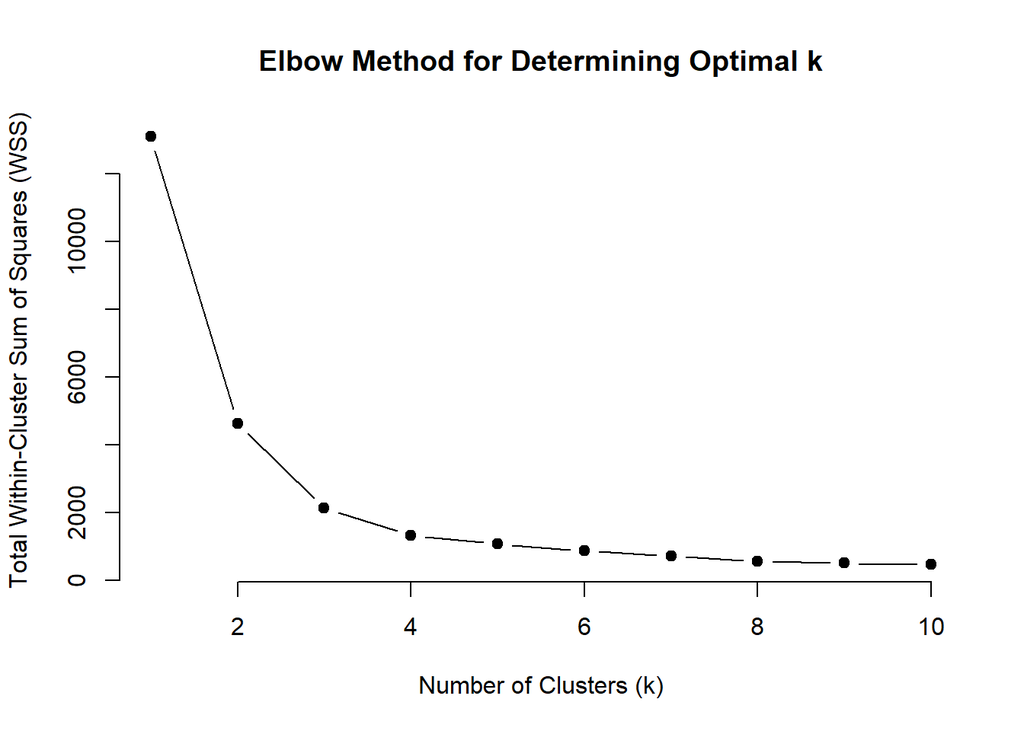

```r
# numeric variables
cluster_data <- C02_data[, c("co2", "population", "temperature_change_from_co2")]

# Scaling
cluster_scaled <- scale(cluster_data)

# Computing total within-cluster sum of squares for k = 1 to 10
set.seed(123)
wss <- numeric(10)
for (k in 1:10) {
  kmeans_model <- kmeans(cluster_scaled, centers = k, nstart = 25)
  wss[k] <- kmeans_model$tot.withinss
}

# here l will plot using the Elbow Method
plot(1:10, wss, type = "b",
     pch = 19, frame = FALSE,
     xlab = "Number of Clusters (k)",
     ylab = "Total Within-Cluster Sum of Squares (WSS)",
     main = "Elbow Method for Determining Optimal k")
```

##### The “elbow” of the curve is located at k = 3. This is the point after which adding more clusters yields diminishing returns. Therefore, the Elbow Method suggests that 3 is the optimal number of clusters for segmenting this dataset based on co2, population, and temperature_change_from_co2.

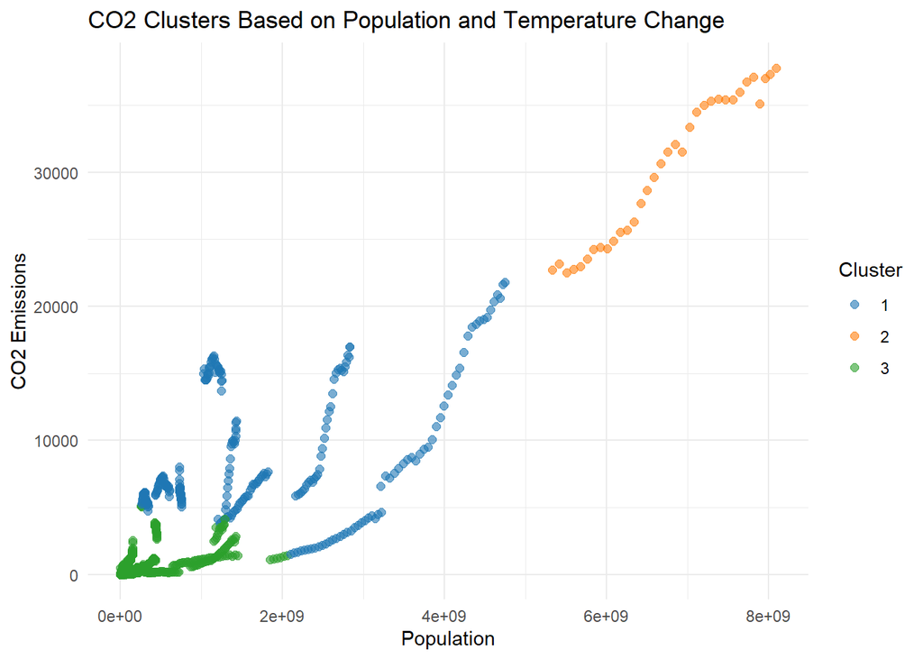

```r
set.seed(123)
C02_scaled <- scale(C02_data[, c("co2", "population", "temperature_change_from_co2")])
kmeans_result <- kmeans(C02_scaled, centers = 3, nstart = 25)

C02_data$Cluster <- as.factor(kmeans_result$cluster)


# Visualizing clusters
library(ggplot2)

ggplot(C02_data, aes(x = population, y = co2, color = Cluster)) +
  geom_point(alpha = 0.6, size = 2) +
  scale_color_manual(values = c("#1f77b4", "#ff7f0e", "#2ca02c")) +
  labs(title = "CO2 Clusters Based on Population and Temperature Change",
       x = "Population",
       y = "CO2 Emissions",
       color = "Cluster") +
  theme_minimal()
```

##### This small, distinct group includes entities with extremely high population and CO₂ levels.

##### It likely corresponds to the aggregated ‘World’ or continental data, where emissions are at their global peak.

##### These points are clearly separated from the rest, indicating a unique emission pattern at the global scale.

# Market Basket / Association Rule Mining

```r
  # Step 5: Association Rule Mining
library(arules); library(arulesViz)
assoc_data <- C02_data[, c("co2", "population", "temperature_change_from_co2")]
assoc_data[] <- lapply(assoc_data, function(x) cut(x, 3, labels = c("Low", "Med", "High")))

rules <- apriori(as(assoc_data, "transactions"), parameter = list(supp=0.05, conf=0.8, minlen=2))
```

```
## Apriori
##
## Parameter specification:
##  confidence minval smax arem  aval originalSupport maxtime support minlen
##         0.8    0.1    1 none FALSE            TRUE       5    0.05      2
##  maxlen target  ext
##      10  rules TRUE
##
## Algorithmic control:
##  filter tree heap memopt load sort verbose
##     0.1 TRUE TRUE  FALSE TRUE    2    TRUE
##
## Absolute minimum support count: 218
##
## set item appearances ...[0 item(s)] done [0.00s].
## set transactions ...[9 item(s), 4369 transaction(s)] done [0.00s].
## sorting and recoding items ... [3 item(s)] done [0.00s].
## creating transaction tree ... done [0.00s].
## checking subsets of size 1 2 3 done [0.00s].
## writing ... [9 rule(s)] done [0.00s].
## creating S4 object  ... done [0.00s].
```

```r
inspect(head(sort(rules, by="lift"), 10))
```

```
##     lhs                                  rhs                                 support confidence  coverage     lift count
## [1] {population=Low,
##      temperature_change_from_co2=Low} => {co2=Low}                         0.9711604  0.9990582 0.9720760 1.021743  4243
## [2] {co2=Low}                         => {temperature_change_from_co2=Low} 0.9777981  1.0000000 0.9777981 1.015574  4272
## [3] {co2=Low,
##      population=Low}                  => {temperature_change_from_co2=Low} 0.9711604  1.0000000 0.9711604 1.015574  4243
## [4] {temperature_change_from_co2=Low} => {co2=Low}                         0.9777981  0.9930265 0.9846647 1.015574  4272
## [5] {co2=Low}                         => {population=Low}                  0.9711604  0.9932116 0.9777981 1.013865  4243
## [6] {population=Low}                  => {co2=Low}                         0.9711604  0.9913551 0.9796292 1.013865  4243
## [7] {co2=Low,
##      temperature_change_from_co2=Low} => {population=Low}                  0.9711604  0.9932116 0.9777981 1.013865  4243
## [8] {population=Low}                  => {temperature_change_from_co2=Low} 0.9720760  0.9922897 0.9796292 1.007744  4247
## [9] {temperature_change_from_co2=Low} => {population=Low}                  0.9720760  0.9872152 0.9846647 1.007744  4247
```

```r
plot(head(sort(rules, by="lift"), 10), method="graph", engine="htmlwidget")
```

[interactive chart not shown]